# Análisis del Consumo de Café y sus Impactos en Estudiantes de UTEC durante el Semestre 2024-II

Grupo 2: Miranda Salazar, Antoni Cotrina, Alexandro Silva, Eloy Nunayalle

## Antecedentes

**Relevancia:** Estando el consumo de café tan presente en la vida cotidiana, por una variedad de razones, es importante analizar tanto los hábitos de consumo asociados a él como sus impactos.

**Contexto:** La población objetivo son los estudiantes de pregrado en UTEC que consumen café. Se utilizó un muestreo aleatorio simple. Los datos se recolectaron del 16 al 24 de septiembre mediante una encuesta en línea accesible por un QR en la universidad. La encuesta tenía preguntas generales y específicas, filtrando con una pregunta sobre el consumo de café dando así una fuente de datos primaria.

## Objetivos

**General:**

Investigar sobre el consumo de café y su impacto en los estudiantes de pregrado de la Universidad de Ingeniería y Tecnología (UTEC) durante el semestre académico 2024-II

**Específicos:**

- Averiguar el impacto autopercibido del café en el rendimiento académico de los estudiantes de UTEC.
- Averiguar los hábitos de consumo de los estudiantes de UTEC respecto al café y determinar la presencia de una cultura cafetera.

## Variables

**Objetivo 1:**

| **Variable** | **Tipo de variable** | **Parámetros** |
| --- | --- | --- |
| **Promedio** | Cuantitativa continua | Valores entre 0 y 20 |
| **Consumo_antes_univ** | Cuantitativa discreta | Valores enteros de 0 a 20 tazas diarias |
| **Consumo_examen_dia** | Cuantitativa discreta | Valores enteros de 0 a 30 tazas diarias |
| **Tiempo extra cafe** | Cualitativa ordinal | No dedico tiempo extra, Menos de 20 minutos, Entre 20 a 40 minutos, Más de 40 minutos |
| **Animo_cafe** | Cualitativa nominal | Despierto, Ansioso, Concentrado, Estresado, Somnoliento, Sin diferencia/neutral, Feliz |

**Objetivo 2:**

| **Variable** | **Tipo de variable** | **Parámetros** |
| --- | --- | --- |
| **Gasto_semanal_cafe** | Cuantitativa continua | Valores entre 0 y 300 soles semanales |
| **Tazas_por_dia** | Cuantitativa discreta | Valores enteros de 1 a 99 tazas diarias |
| **Frecuencia_Reunion** | Cualitativa ordinal | Nunca, Rara vez, Algunas veces, Siempre |
| **Frecuencia_cafeterias_semana** | Cualitativa ordinal | 0, 1, 2, 3, 4 a más |
| **Establecimiento_compra** | Cualitativa nominal | Bodegas como Listo, Tambo, etc.; Starbucks; Hago mi propio café; Cafetería artesanal |

## Análisis descriptivo

#### Correlación de Frecuencia reunión en cafeterías y Establecimientos de compra de café

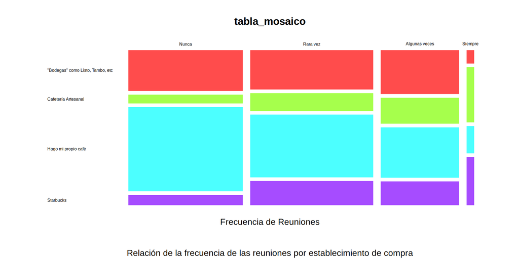

#### Correlación de Tazas por día y Promedio

```
[1] "Coeficiente de correlación entre Tazas por día y Promedio académico:-0.0317927114864019"
```

```
[1] "La ecuación de regresión para un modelo lineal es: y = -0.0227207907761266x + 14.7604636282393"
```

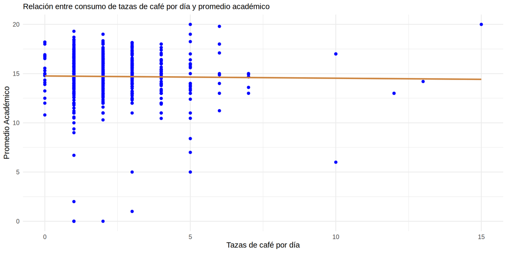

## Probabilidad Empírica

**Experimento Aleatorio 1** ($EA_{1}$): Rendimiento Académico

Seleccionar al azar un estudiante y observar su promedio académico.

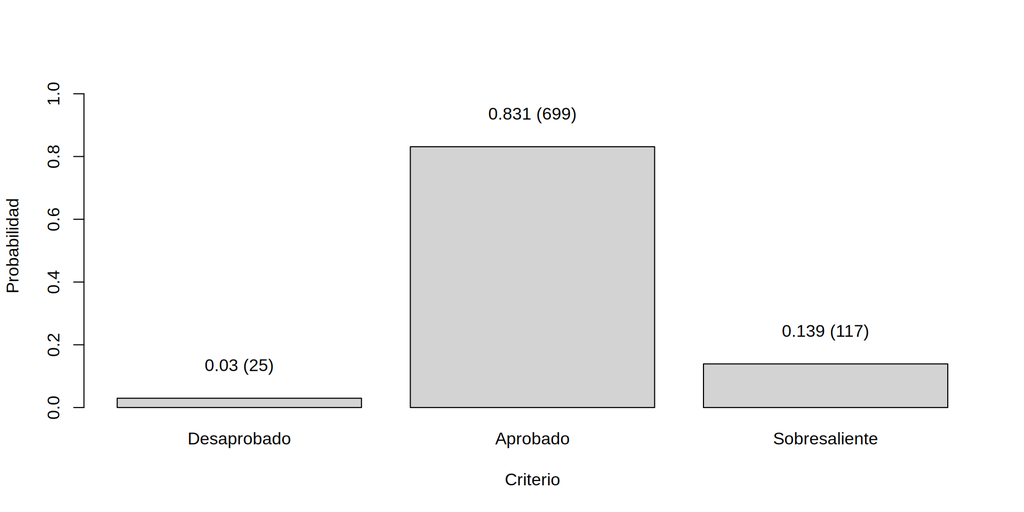

**Experimento Aleatorio 2** ($EA_{2}$): Frecuencia de Reunión para Tomar Café

Seleccionar al azar un estudiante y observar su frecuencia de reunión para tomar café.

[figure not shown]

- Conclusión: Predomina una baja frecuencia de reuniones, siendo “Rara vez” ($37.93\%$) la categoría más común.

## Probabilidad Condicional

**Primer Caso**

**Eventos**

- $E_1$: Seleccionar un estudiante con promedio aprobatorio ($11 \leq Promedio \leq 20$).
- $E_2$: Seleccionar un estudiante que consume de 0 a 3 tazas de café el día del examen.

**Cálculos**

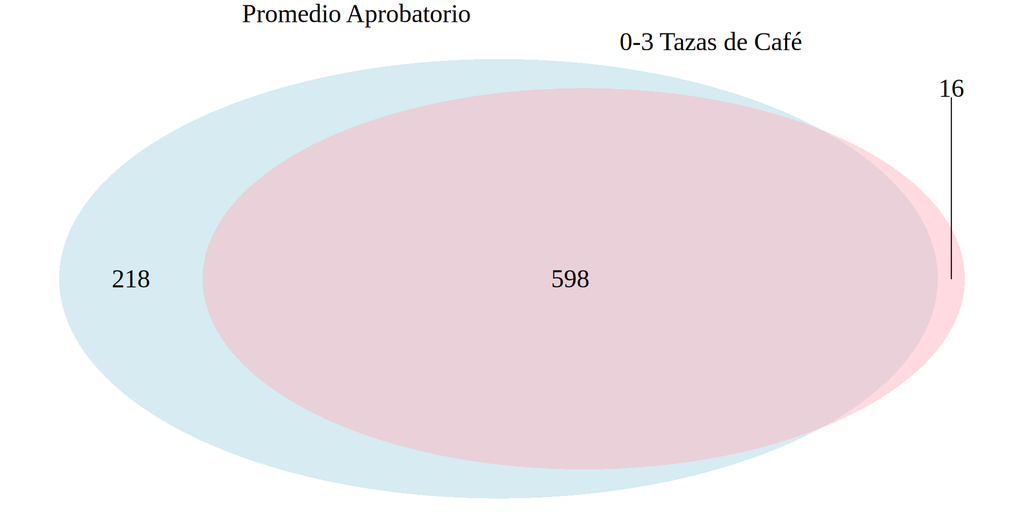

```
P(E1): 0.97
```

```
P(E2): 0.73
```

```
P(E1 ∩ E2): 0.71
```

```
Independencia: P(E1 ∩ E2) = P(E1)*P(E2): TRUE
```

**Segundo Caso**

**Eventos**

- $E_1$: Gasto semanal bajo ($0 \leq Gasto < 50$).
- $E_2$: Gasto semanal medio ($50 \leq Gasto \leq 100$).
- $E_3$: Prefiere Starbucks o cafeterías artesanales.

**Probabilidades condicionales**

1. $P(E_3|E_1)$: Probabilidad de que un estudiante frecuente Starbucks o cafeterías artesanales si gasta hasta 50 soles semanalmente.
2. $P(E_3|E_2)$: Probabilidad de que un estudiante frecuente Starbucks o cafeterías artesanales si gasta entre 50 y 100 soles semanalmente.

```
    Evento Probabilidad Frecuencia
1    P(E1)         0.92        776
2    P(E2)         0.07         61
3    P(E3)         0.26        221
4 P(E3|E1)         0.24        187
5 P(E3|E2)         0.49         30
```

```
[1] "¿E1 y E3 son independientes?: FALSE"
```

```
[1] "¿E2 y E3 son independientes?: FALSE"
```

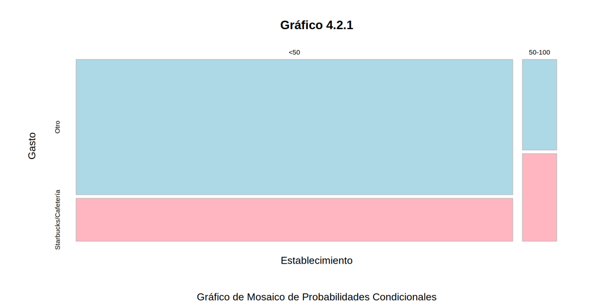

## Variables Aleatorias Discretas

**Distribución hipergeométrica**

**Tiempo de estudio extra al consumir café**

Se desea conocer la probabilidad de encontrar 20 estudiantes que estudian más de 40 minutos si se toma una muestra de 30 estudiantes.

```
Total de estudiantes:  841
```

```
Número de casos con éxito en la población:  346
```

```
Tamaño de la muestra:  30
```

```
Número de éxitos en la muestra : 20
```

**Probabilidad dhyper(xo,m,n,k)“**

[output not shown]

**Propiedades**

```
[1] "E(X): 12.34"
```

```
[1] "V(X): 7.01"
```

```
[1] "CV: 0.21"
```

**Distribución binomial**

**Frecuencia de reunión en cafeterías**

Se desea conocer la probabilidad de que, al seleccionar 10 estudiantes al azar con reposición, al menos la mitad de ellos tengan una frecuencia de reunión de “Algunas veces” o de “Siempre”.

```
Cantidad de éxitos acumulados deseados: 5
```

```
Cantidad de alumnos seleccionados: 10
```

```
Probabilidad empirica del éxito: 0.2675386
```

**Probabilidad pbinom(x,n,p)“**

[output not shown]

**Propiedades**

```
[1] "E(X): 2.68"
```

```
[1] "V(X): 1.96"
```

[output not shown]

## Variables Aleatorias Continuas

**Distribución exponencial**

**Gasto semanal en café**

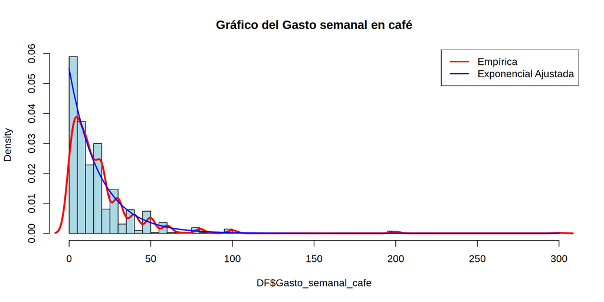

**Propiedades:**

```
[1] "Tasa lambda: 0.05"
```

```
[1] "Esperanza (mu): 18.24"
```

```
[1] "Varianza (sigma^2): 332.59"
```

```
[1] "Desviación Estándar (sigma): 18.24"
```

**Distribución normal**

**Promedio**

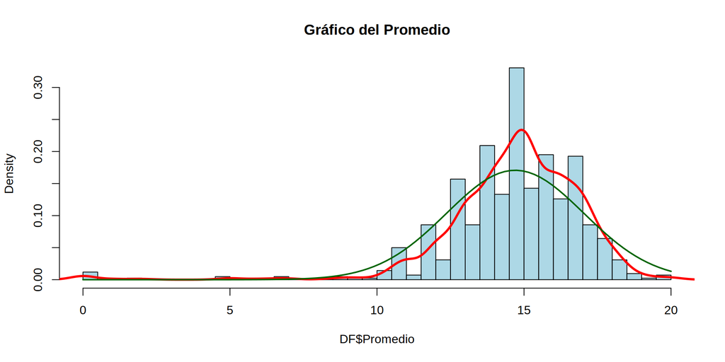

```
[1] "Moda: 15"
```

```
[1] "Media: 14.7"
```

```
[1] "Mediana: 15"
```

**Propiedades**

```
[1] "Sigma: 2.34"
```

[output not shown]

[output not shown]

## Conclusiones

Esta investigación analiza el consumo de café y su impacto en los estudiantes de pregrado de la UTEC durante el semestre académico 2024-II, revelando patrones interesantes.

Respecto a los hábitos de consumo, la mayoría de los estudiantes consume poco café, prefiriendo prepararlo en casa o visitar cafeterías artesanales ocasionalmente. Los consumidores frecuentes, en cambio, suelen acudir a cafeterías artesanales o tiendas reconocidas, reflejando una cultura cafetera más desarrollada.

Entre las limitaciones destacan la limpieza de datos, que redujo la muestra a 841 estudiantes, y posibles sesgos en las respuestas.